[O’Hara on GitHub](https://github.com/oharac)

# Calculate species sensitivity from traits

Compiled on Mon Aug 10 17:26:34 2020 by ohara

```r
knitr::opts_chunk$set(fig.width = 6, fig.height = 4, fig.path = 'figs/',
                      echo = TRUE, message = FALSE, warning = FALSE)

source('https://raw.githubusercontent.com/oharac/src/master/R/common.R')
```

# 1 Summary

Read in Excel spreadsheets of taxonomic traits filled in by taxon experts. Process into a long/tidy format with checks on validity of category values. Identify categories that were assigned non-valid values.

# 2 Data

`_raw_data/all_taxa_trait_data.xlsx` is the raw workbook prepared by Nathalie Butt from the various submissions of the taxa-group experts. This has been processed and cleaned to `_data/spp_traits_valid.csv`.

`excel_files/trait_stressor_sens_tidy.xlsx` is a workbook with each sheet indicating a stressor, and sensitivity scores for each trait with respect to that stressor.

# 3 Methods

## 3.1 Use scored sensitivity traits to stressors against species scored to traits

```r
str_sens_traits_file <- here('trait_stressor_rankings/trait_stressor_sens.xlsx')
layers <- readxl::excel_sheets(str_sens_traits_file)
str_sens_trait_scores <- lapply(layers,
        FUN = function(l) { # l <- layers[1]
          df <- readxl::read_excel(str_sens_traits_file, sheet = l) %>%
            mutate(stressor = l)
          if(class(df$sens_score) == 'character') {
            df <- df %>%
              mutate(sens_score = case_when(
                str_detect(tolower(sens_score), '^y') ~ 1,
                str_detect(tolower(sens_score), '^n') ~ 0,
                TRUE ~ NA_real_))
          }
          return(df)
        }) %>%
  bind_rows() %>%
  mutate(trait_val_clean = str_replace_all(tolower(trait_value), '[^0-9a-z<>]', ''),
         category = tolower(category))



spp_traits <- read_csv('_data/spp_traits_valid.csv') %>%
  mutate(trait_val_clean = str_replace_all(tolower(trait_val), '[^0-9a-z<>]', ''))

spp_sens <- spp_traits %>%
  left_join(str_sens_trait_scores, by = c('category', 'trait', 'trait_val_clean')) %>%
  filter(!is.na(stressor)) %>%
  group_by(spp_gp, stressor, sheet) %>%
  summarize(sens_score = sum(sens_score, na.rm = TRUE))
```

```r
y <- str_sens_trait_scores %>%
  filter(stressor == 'wildlife_strike') %>%
  select(category, trait, trait_val = trait_value, s = sens_score) %>%
  group_by(category, trait) %>%
  filter(any(s > 0)) %>%
  ungroup() %>%
  distinct()

vaq_df <- spp_traits %>%
  filter(str_detect(tolower(spp_gp), '^vaquita')) %>%
  right_join(y, by = c('category', 'trait', 'trait_val')) %>%
  mutate(spp_trait = ifelse(is.na(spp_gp), 0, 1)) %>%
  select(trait, trait_val, v = spp_trait)
auk_df <- spp_traits %>%
  filter(str_detect(tolower(spp_gp), '^auks')) %>%
  right_join(y, by = c('category', 'trait', 'trait_val')) %>%
  mutate(spp_trait = ifelse(is.na(spp_gp), 0, 1)) %>%
  select(trait, trait_val, a = spp_trait)

combo_df <- y %>%
  select(-category) %>%
  mutate(a = auk_df$a,
         v = vaq_df$v)

# s <- y$sens_score
# v <- vaq_df$spp_trait
# a <- auk_df$spp_trait
#
# t(s) %*% v
# t(s) %*% a
```

The method here is to take a vector of trait values for a species, and multiply it by a vector of stressor sensitivities per trait. So a simplified version is:

Vector $\mathbf{s}$ of sensitivity to wildlife strike stressors based on traits:

| trait | trait_val | s |
| --- | --- | --- |
| depth (min/max) | epipelagic | 1 |
| depth (min/max) | mesopelagic | 0 |
| depth (min/max) | bathypelagic | 0 |
| depth (min/max) | abyssopelagic | 0 |
| depth (min/max) | hadopelagic | 0 |
| air-sea interface | floating | 1 |
| air-sea interface | yes | 1 |
| air-sea interface | no | 0 |
| terrestrial and marine life stages | yes | 1 |
| terrestrial and marine life stages | no | 0 |
| adult body mass/body size | >1000 mm | 1 |
| adult body mass/body size | 50 mm-999 mm | 0 |
| adult body mass/body size | 0.5-49 mm | 0 |
| adult body mass/body size | <0.4 mm | 0 |
| adult body mass/body size | unknown | 0 |
| respiration structures | lungs | 1 |
| respiration structures | gills | 0 |
| respiration structures | skin | 0 |
| respiration structures | diffusion | 0 |
| respiration structures | pneumatophores | 0 |
| respiration structures | filter feeders | 0 |

Vector $\mathbf{v}$ of trait presence for Vaquita:

| trait | trait_val | v |
| --- | --- | --- |
| depth (min/max) | epipelagic | 1 |
| depth (min/max) | mesopelagic | 0 |
| depth (min/max) | bathypelagic | 0 |
| depth (min/max) | abyssopelagic | 0 |
| depth (min/max) | hadopelagic | 0 |
| air-sea interface | floating | 0 |
| air-sea interface | yes | 0 |
| air-sea interface | no | 0 |
| terrestrial and marine life stages | yes | 0 |
| terrestrial and marine life stages | no | 1 |
| adult body mass/body size | >1000 mm | 0 |
| adult body mass/body size | 50 mm-999 mm | 0 |
| adult body mass/body size | 0.5-49 mm | 0 |
| adult body mass/body size | <0.4 mm | 0 |
| adult body mass/body size | unknown | 0 |
| respiration structures | lungs | 1 |
| respiration structures | gills | 0 |
| respiration structures | skin | 0 |
| respiration structures | diffusion | 0 |
| respiration structures | pneumatophores | 0 |
| respiration structures | filter feeders | 0 |

Vector multiply: $\mathbf{s}^T\mathbf{v} = 2$

Vector $\mathbf{a}$ of trait presence for Auks:

| trait | trait_val | a |
| --- | --- | --- |
| depth (min/max) | epipelagic | 1 |
| depth (min/max) | mesopelagic | 0 |
| depth (min/max) | bathypelagic | 0 |
| depth (min/max) | abyssopelagic | 0 |
| depth (min/max) | hadopelagic | 0 |
| air-sea interface | floating | 0 |
| air-sea interface | yes | 1 |
| air-sea interface | no | 0 |
| terrestrial and marine life stages | yes | 1 |
| terrestrial and marine life stages | no | 0 |
| adult body mass/body size | >1000 mm | 0 |
| adult body mass/body size | 50 mm-999 mm | 1 |
| adult body mass/body size | 0.5-49 mm | 0 |
| adult body mass/body size | <0.4 mm | 0 |
| adult body mass/body size | unknown | 0 |
| respiration structures | lungs | 1 |
| respiration structures | gills | 0 |
| respiration structures | skin | 0 |
| respiration structures | diffusion | 0 |
| respiration structures | pneumatophores | 0 |
| respiration structures | filter feeders | 0 |

Vector multiply: $\mathbf{s}^T\mathbf{a} = 4$

See vectors side by side:

| trait | trait_val | s | a | v |
| --- | --- | --- | --- | --- |
| depth (min/max) | epipelagic | 1 | 1 | 1 |
| depth (min/max) | mesopelagic | 0 | 0 | 0 |
| depth (min/max) | bathypelagic | 0 | 0 | 0 |
| depth (min/max) | abyssopelagic | 0 | 0 | 0 |
| depth (min/max) | hadopelagic | 0 | 0 | 0 |
| air-sea interface | floating | 1 | 0 | 0 |
| air-sea interface | yes | 1 | 1 | 0 |
| air-sea interface | no | 0 | 0 | 0 |
| terrestrial and marine life stages | yes | 1 | 1 | 0 |
| terrestrial and marine life stages | no | 0 | 0 | 1 |
| adult body mass/body size | >1000 mm | 1 | 0 | 0 |
| adult body mass/body size | 50 mm-999 mm | 0 | 1 | 0 |
| adult body mass/body size | 0.5-49 mm | 0 | 0 | 0 |
| adult body mass/body size | <0.4 mm | 0 | 0 | 0 |
| adult body mass/body size | unknown | 0 | 0 | 0 |
| respiration structures | lungs | 1 | 1 | 1 |
| respiration structures | gills | 0 | 0 | 0 |
| respiration structures | skin | 0 | 0 | 0 |
| respiration structures | diffusion | 0 | 0 | 0 |
| respiration structures | pneumatophores | 0 | 0 | 0 |
| respiration structures | filter feeders | 0 | 0 | 0 |

Note that vaquita aren’t listed as being at the air-sea interface… and while they’re wee, they’re bigger than a meter I am pretty sure. So vaquita should really be scored a 4. And the mammal sheet should be checked over.

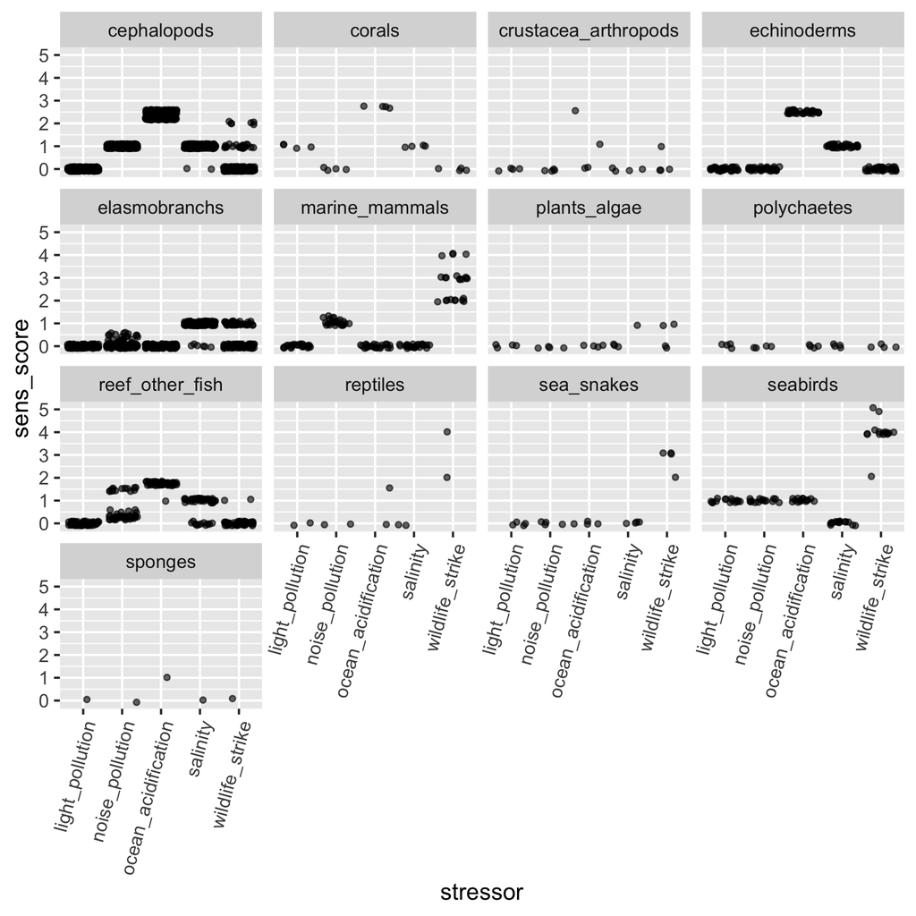

```r
p <- ggplot(spp_sens, aes(x = stressor, y = sens_score)) +
  geom_jitter(size = 1, alpha = .6) +
  theme(axis.text.x = element_text(angle = 75, hjust = 1)) +
  facet_wrap(~ sheet)

ggsave(here('figs/spp_sens_text.png'), height = 6, width = 6, dpi = 300)

knitr::include_graphics(here('figs/spp_sens_text.png'))
```

### 3.1.1 try adaptive capacity traits…

later!

```r
str_adcap_traits_file <- here('trait_stressor_rankings/trait_stressor_adcap.xlsx')
```